*October 8, 2023*

# Festive Season Frenzy: Affle (India) Limited - Your Stock Pick for the Online Sales Surge!

*Affle (India) Limited (NSE:AFFLE), a leading player in mobile advertisement services and software development, is poised for significant growth as the upcoming festive season in India promises a remarkable surge in online sales. This surge is expected to have a positive impact on the company's stock price.*

### About

Affle (India) Limited, together with its subsidiaries, provides mobile advertisement services through information technology and software development services for mobiles in India and internationally. It operates through Consumer Platform and Enterprise Platform segments. The company provides reselling services of advertisement space for online publishing companies; and customized mobile app development services.

## Introduction

Affle (India) Limited, a company specializing in mobile advertisement services and software development, is gearing up for a potentially lucrative festive season. Recent reports indicate that the Indian market is set to witness a staggering demand of Rs 90,000 crore in online sales, with expectations of a 15% increase in job opportunities during this period. Additionally, it is anticipated that loan applications will rise by 40-50%, surpassing 10 lakh applications during the festive season.

### Positive Impact on Affle (India) Limited's Stock Price:

The following factors will results in a positive impact on the stock price of Affle.

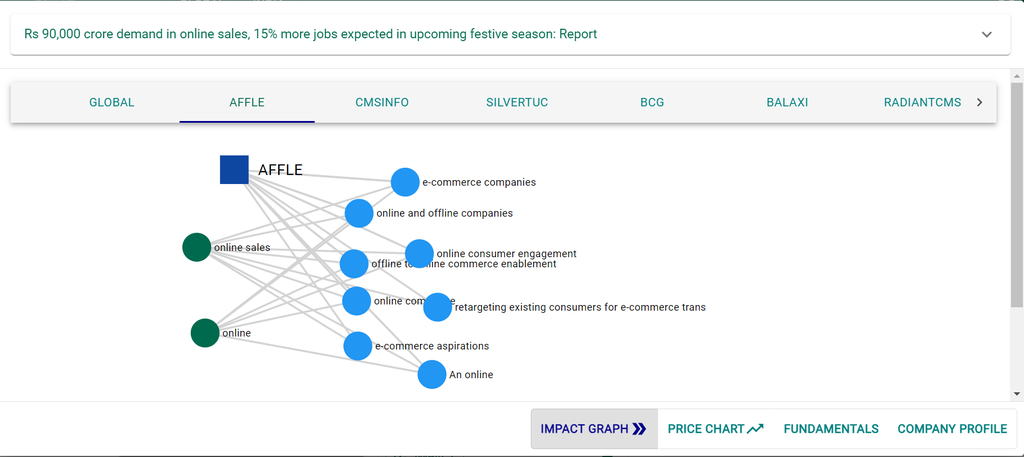

*The above shows graph linking the concepts of online sales to concepts about Affle. The insight was gained using the CausalityArrow platform: [CausalityArrow](https://causalityarrow.com/home/) Please contact the author for a free trial account.*

The impact of the upcoming festive season on the price of Affle can be understood as follows:

**Increased Advertising Demand**: With the surge in online sales, businesses across various sectors will be vying for consumers' attention. This is where Affle's mobile advertisement services come into play. As companies seek to capitalize on the festive season, the demand for effective digital advertising solutions is likely to soar. Affle's Consumer Platform, which provides reselling services of advertisement space for online publishing companies, is poised to witness increased demand, potentially resulting in higher revenues.

**Customized Mobile App Development**: Affle also offers customized mobile app development services. As e-commerce businesses and other sectors look to enhance their online presence and offer seamless customer experiences during the festive rush, the demand for mobile apps is expected to rise. Affle's expertise in this area positions the company favorably to cater to this growing demand.

**Programmatic Advertising Platforms**: Affle's portfolio includes programmatic advertising platforms such as Mediasmart and Jampp. These platforms enable businesses to target their advertising efforts effectively. As companies look to optimize their marketing budgets and maximize returns during the festive season, the utilization of programmatic advertising solutions is likely to increase, benefiting Affle.

**Data Analytics**: Affle's mDMP (data organize platform) plays a crucial role in understanding consumer behavior and preferences. During the festive season, insights derived from data analytics become invaluable for businesses. As the volume of online transactions surges, Affle's data analytics services may see increased adoption, further contributing to its revenue stream.

**Market Sentiment**: The anticipation of a prosperous festive season, coupled with the positive outlook for the Indian economy, can boost investor sentiment. This optimism can translate into increased interest in Affle (India) Limited's stock, potentially driving its price upward.

### Strong Financial Foundation

In addition to the positive news regarding Affle (India) Limited's anticipated growth during the upcoming festive season, it's important to underscore the company's robust financial performance over the last five years. These impressive financials further bolster the company's investment appeal.

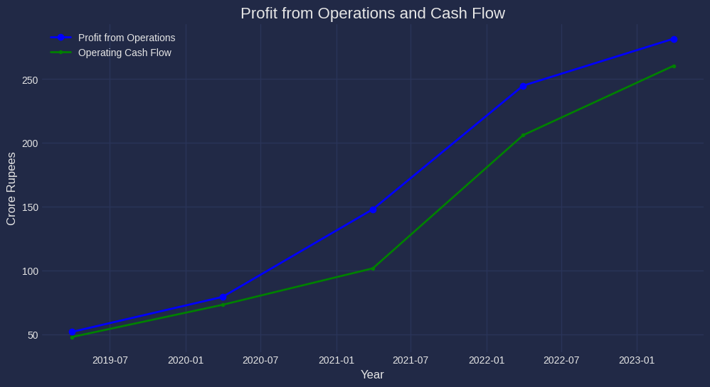

The above figure shows the growth of profit and cash flow for the last 5 years.

**Consistent Profit Growth**: Over the past half-decade, Affle has exhibited remarkable consistency in its profit growth. The company's net profit has surged by an astonishing 443% during this period, with a Compound Annual Growth Rate (CAGR) of 40.3%. This stellar performance reflects the company's ability to generate substantial earnings year after year, a crucial indicator of its financial stability.

**Healthy Cash Flow Position**: Affle has not only been profitable but has also demonstrated impressive cash flow growth. With a remarkable increase of 444% in cash flow over the last five years, the company maintains a robust financial position. This consistent cash flow growth showcases its ability to generate cash and support its ongoing operations and expansion initiatives.

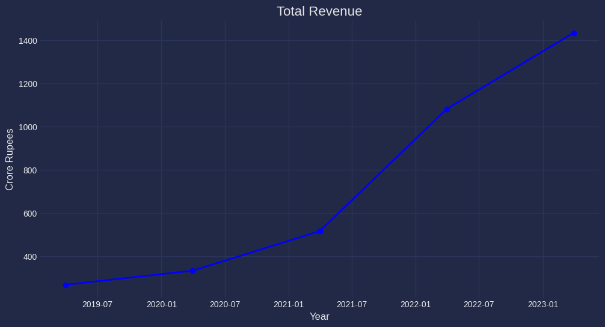

**Strong Revenue Growth**: Affle's total revenue growth of 433% over the past five years, boasting a CAGR of 39.79%, indicates its capacity to capture market share and expand its top-line performance. This sustained revenue growth underscores the company's competitiveness in the mobile advertising and software development sectors.

**Virtually Debt-Free**: One of the most compelling aspects of Affle's financial profile is its virtually debt-free status. A lack of significant debt burdens enhances the company's financial resilience and minimizes risk, further appealing to investors seeking stability and growth potential.

**Healthy Interest Coverage Ratio**: The interest coverage ratio, an indicator of a company's ability to meet its interest payments, stands at an impressive 458.06 for Affle. This robust ratio not only highlights the company's capacity to service its debts comfortably but also reinforces its financial soundness.

**Efficient Cash Conversion Cycle**: Affle boasts an efficient Cash Conversion Cycle (CCC) of 68.55 days. This signifies the company's adeptness in converting its investments in inventory and other resources into cash, optimizing its working capital management, and supporting its growth strategies.

**Healthy Liquidity Position**: Affle maintains a strong liquidity position with a current ratio of 4.08. This ratio, which measures the company's ability to cover its short-term liabilities with its current assets, indicates a comfortable cushion to meet obligations and seize growth opportunities without liquidity constraints.

## Conclusions

The upcoming festive season in India is set to be a boon for Affle (India) Limited. The expected surge in online sales bodes well for the company's mobile advertisement services, app development solutions, and programmatic advertising platforms. With its diverse portfolio catering to the digital advertising ecosystem, Affle is well-positioned to capitalize on the festive fervor. In conjunction with the promising news of a surge in online sales during the upcoming festive season, Affle (India) Limited's exceptional financial performance over the past five years reinforces its position as a solid investment choice. With substantial profit and cash flow growth, strong revenue generation, a debt-free status, impressive interest coverage, efficient working capital management, and a healthy liquidity position, the company's financials provide a solid foundation for continued growth. This financial strength further augments investor confidence and supports the expectation of a positive impact on Affle's stock price in the foreseeable future. As a result, investors may find the company's stock an attractive option, potentially leading to a positive impact on its stock price in the coming months.

### Reference

Rs 90,000 crore demand in online sales, 15% more jobs expected in upcoming festive season: Report

Author: Dr. Chetan Nichkawde  
Email: chetan.nichkawde@gmail.com

Disclaimer: I wrote this article myself, and it expresses my own opinions. I am not receiving compensation for it. I have no business relationship with any company whose stock is mentioned in this article. Past performance is no guarantee of future results. The article is not a recommendation or advice as to whether any investment is suitable for a particular investor.